# Machine Learning Project: UAP/UFO Sightings from National UFO Research Center (NUFORC)

## Build a LinearRegression model

```python
# perform a GridSearchCV to get the best parameter values to build the model
model = LinearRegression()
param_grid = {'fit_intercept': [True, False], 'n_jobs': [None,-1,2,4],
              'positive': [True, False], }
# Define scoring function
def neg_rmse(y_true, y_pred):
    return -mean_squared_error(y_true, y_pred, squared=False)

# Define grid search
grid = GridSearchCV(model, param_grid, scoring=neg_rmse, cv=5)

# Fit grid search
grid.fit(X_train, y_train)

# Print best parameters and best score
print("Best parameter values: ", grid.best_params_)
print("Best score: ", grid.best_score_)
```

```
Best parameter values:  {'fit_intercept': True, 'n_jobs': None, 'positive': True}
Best score:  nan
```

```python
# train a linear regression model
modelLR = LinearRegression(fit_intercept=True, positive=True)
modelLR.fit(X_train, y_train)

# make predictions on the testing data and print predictions and actual values
y_pred = modelLR.predict(X_test)
lr_pred = y_pred    # for model analysis later
print("Predicted frequencies: ", y_pred)
print("Actual frequencies: ", y_test.values.tolist()[:3]," ... ", y_test.values.tolist()[-3:])

# evaluate the model performance using mse, mae, and R2
mseLR = mean_squared_error(y_test, y_pred)
print(f"Mean squared error: {mseLR:.2f}")
maeLR = mean_absolute_error(y_test, y_pred)
print(f"Mean absolute error: {maeLR:.2f}")
r2LR = r2_score(y_test, y_pred)
print(f"R2 score: {r2LR:.2f}")

# plot the actual vs predicted values
#plt.scatter(y_test, y_pred)
#plt.xlabel("Actual frequency")
#plt.ylabel("Predicted frequency")
#plt.title("Actual vs Predicted Frequency of UFO Sightings")
#plt.show()
```

```
Predicted frequencies:  [[6.96998409]
 [5.80907539]
 [6.70822889]
 ...
 [5.79522557]
 [6.59257241]
 [5.6019366 ]]
Actual frequencies:  [[2.0], [2.0], [2.0]]  ...  [[3.0], [4.0], [1.0]]
Mean squared error: 30.71
Mean absolute error: 4.55
R2 score: -0.28
```

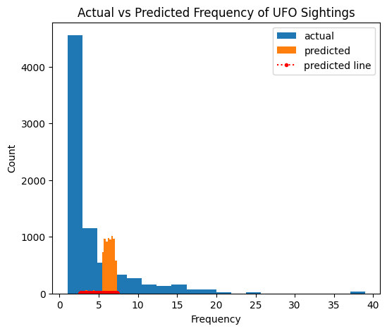

```python
# plot the actual vs predicted values for the model
plt.figure(figsize=(6, 5))

# plot the histogram of actual and predicted values
plt.hist(y_test, label="actual", bins=20)
plt.hist(y_pred, label="predicted", bins=20)

# create an array of x-coordinates for the line graph
x = np.linspace(min(y_pred), max(y_pred), len(y_pred))

# plot the predicted values as a line graph
plt.plot(x, y_pred, color="r", marker=".", linestyle=":", label="predicted line")

# set title and formatting
plt.title("Actual vs Predicted Frequency of UFO Sightings")
plt.legend(loc="upper right")
plt.xlabel("Frequency")
plt.ylabel("Count")
plt.savefig("plots/lr_freq_plot.png")
plt.show()
```

## Build a Lasso Regression model to predict frequency of UFO sightings

## Figure out what alpha value to use in Lasso model

```python
# perform a LassoCV cross validation to get the best parameter values to build the model
# create and fit a LassoCV model with 5-fold cross-validation
reg = LassoCV(cv=5, random_state=42).fit(X, y)

# display alpha to use and score
print("Best alpha parameter value: ", reg.alphas)
print("Training score: ", reg.score(X, y))

# predict on actual data and evaluate the performance
y_pred = reg.predict(X_test)
print("MSE Score: ", mean_squared_error(y_test, y_pred))
```

```
Best alpha parameter value:  None
Training score:  0.01841182966491206
MSE Score:  26.54813298777757
```

```python
# build a Lasso regressor model
modelLS = Lasso(random_state=42) # Use Lasso class with no alpha parameter, default is alpha=1.0

# fit the model to the data
modelLS.fit(X_train, y_train)

# make predictions on the testing data and print predictions and actual values
y_pred = modelLS.predict(X_test)
ls_pred = y_pred    # for analysis later
print("Predicted frequencies: ", y_pred)
print("Actual frequencies: ", y_test.values.tolist()[:3]," ... ", y_test.values.tolist()[-3:])

# evaluate the model performance using mse, mae, and R2
mseLS = mean_squared_error(y_test, y_pred)
print(f"Mean squared error: {mseLS:.2f}")
maeLS = mean_absolute_error(y_test, y_pred)
print(f"Mean absolute error: {maeLS:.2f}")
r2LS = r2_score(y_test, y_pred)
print(f"R2 score: {r2LS:.2f}")
```

```
Predicted frequencies:  [6.86121893 5.70162432 6.59976003 ... 5.68747987 6.47651065 5.48589205]
Actual frequencies:  [[2.0], [2.0], [2.0]]  ...  [[3.0], [4.0], [1.0]]
Mean squared error: 30.18
Mean absolute error: 4.48
R2 score: -0.25
```

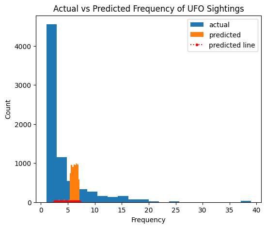

```python
# plot the actual vs predicted values for the model
plt.figure(figsize=(6, 5))

# plot the histogram of actual and predicted values
plt.hist(y_test, label="actual", bins=20)
plt.hist(y_pred, label="predicted", bins=20)

# create an array of x-coordinates for the line graph
x = np.linspace(min(y_pred), max(y_pred), len(y_pred))
# plot the predicted values as a line graph
plt.plot(x, y_pred, color="r", marker=".", linestyle=":", label="predicted line")

# set title and formatting
plt.title("Actual vs Predicted Frequency of UFO Sightings")
plt.legend(loc="upper right")
plt.xlabel("Frequency")
plt.ylabel("Count")
plt.savefig("plots/ls_freq_plot.png")
plt.show()
```

## Build a DecisionTreeRegressor model to predict frequency of UFO sightings

# perform a GridSearchCV to get the best parameter values to build the model

# define parameter grid to test out parameter values

param_grid = {

```
# criterion used in previous GridSearch: 'friedman_mse', 'absolute_error', 'squared_error', 'poisson'
"criterion": ['squared_error', 'poisson'],
# max_depth used in previous GridSearch: : 2, 3, 4, 5
"max_depth": [3, 4, 5, 6],
"min_samples_split": [1,2,3]
```

}

# create a GridSearchCV object with DecisionTreeRegressor and the parameter grid

grid_search = GridSearchCV(DecisionTreeRegressor(), param_grid, cv=5, scoring="neg_mean_squared_error")

# fit the grid search on the training data

grid_search.fit(X_train, y_train)

# print out best parameters and the best score

# predict values for the testing data using the best estimator

# evaluate the performance

mse = mean_squared_error(y_test, y_pred) print("Mean squared error:", mse)

```python
# create and fit the DecisionTreeRegressor model
modelDT = DecisionTreeRegressor(max_depth=6, criterion="poisson", min_samples_split=2, random_state=42)
modelDT.fit(X_train, y_train)

# make predictions on the testing data and print predictions and actual values
y_pred = modelDT.predict(X_test)
dt_pred = y_pred    # for analysis later
print("Predicted frequencies: ", y_pred)
print("Actual frequencies: ", y_test.values.tolist()[:3]," ... ", y_test.values.tolist()[-3:])

# evaluate the model performance using mse, mae, and R2
mseDT = mean_squared_error(y_test, y_pred)
print(f"Mean squared error: {mseDT:.2f}")
maeDT = mean_absolute_error(y_test, y_pred)
print(f"Mean absolute error: {maeDT:.2f}")
r2DT = r2_score(y_test, y_pred)
print(f"R2 score: {r2DT:.2f}")
```

```
Predicted frequencies:  [7.28762376 4.44591523 7.28762376 ... 1.33941606 7.28762376 2.31736527]
Actual frequencies:  [[2.0], [2.0], [2.0]]  ...  [[3.0], [4.0], [1.0]]
Mean squared error: 28.46
Mean absolute error: 4.01
R2 score: -0.18
```

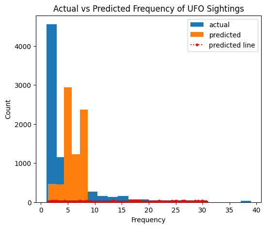

```python
# plot the actual vs predicted values for the model
plt.figure(figsize=(6, 5))

# plot the histogram of actual and predicted values
plt.hist(y_test, label="actual", bins=20)
plt.hist(y_pred, label="predicted", bins=20)

# create an array of x-coordinates for the line graph
x = np.linspace(min(y_pred), max(y_pred), len(y_pred))

# plot the predicted values as a line graph
plt.plot(x, y_pred, color="r", marker=".", linestyle=":", label="predicted line")

# set title and formatting
plt.title("Actual vs Predicted Frequency of UFO Sightings")
plt.legend(loc="upper right")
plt.xlabel("Frequency")
plt.ylabel("Count")
plt.savefig("plots/dt_freq_plot.png")
plt.show()
```

## Build a RandomForestRegressor model to predict frequency of UFO sightings

# perform a GridSearchCV to get the best parameter values to build the model

# define parameter grid to test out parameter values

param_grid = { "n_estimators": [300,400,500,525,550,600],

# "criterion:": ["gini", "entropy", "log_loss"], # Had error of invalid criterion

```
"max_features": ["sqrt", "log2"],
"min_samples_split": [2,4,3]
```

}

# create a GridSearchCV object with RandomForestRegressor and the parameter grid

grid_search = GridSearchCV(RandomForestRegressor(), param_grid, cv=5, scoring="neg_mean_squared_error")

# fit the grid search on the training data

grid_search.fit(X_train, y_train)

# print the best parameters and the best score

# make predictions on the testing data using the best estimator

# evaluate the performance

mse = mean_squared_error(y_test, y_pred) print("Mean squared error:", mse)

```python
# create a random forest regressor model
modelRF = RandomForestRegressor(n_estimators=200, max_features="sqrt", min_samples_split=4, random_state=42)
# fit the model to the train data
modelRF.fit(X_train, y_train)

# make predictions and print out results
y_pred = modelRF.predict(X_test)
rf_pred = y_pred    # for analysis later
print("Predicted frequencies: ", y_pred)
print("Actual frequencies: ", y_test.values.tolist()[:3]," ... ", y_test.values.tolist()[-3:])

# evaluate the model performance using mse, mae, and R2
mseRF = mean_squared_error(y_test, y_pred)
print(f"Mean squared error: {mseRF:.2f}")
maeRF = mean_absolute_error(y_test, y_pred)
print(f"Mean absolute error: {maeRF:.2f}")
r2RF = r2_score(y_test, y_pred)
print(f"R2 score: {r2RF:.2f}")
```

```
Predicted frequencies:  [5.94035714 2.98933333 1.30216667 ... 1.37091667 3.95125    1.19997024]
Actual frequencies:  [[2.0], [2.0], [2.0]]  ...  [[3.0], [4.0], [1.0]]
Mean squared error: 30.10
Mean absolute error: 2.83
R2 score: -0.25
```

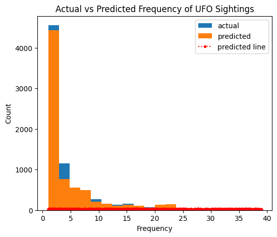

```python
# plot the actual vs predicted values for the model
plt.figure(figsize=(6, 5))

# plot the histogram of actual and predicted values
plt.hist(y_test, label="actual", bins=20)
plt.hist(y_pred, label="predicted", bins=20)

# create an array of x-coordinates for the line graph
x = np.linspace(min(y_pred), max(y_pred), len(y_pred))

# plot the predicted values as a line graph
plt.plot(x, y_pred, color="r", marker=".", linestyle=":", label="predicted line")

# set title and formatting
plt.title("Actual vs Predicted Frequency of UFO Sightings")
plt.legend(loc="upper right")
plt.xlabel("Frequency")
plt.ylabel("Count")
plt.savefig("plots/rf_freq_plot.png")
plt.show()
```

## Build a Stochastic Gradient Descent (SGD) Regressor model to predict frequency of UFO sightings

# perform a GridSearchCV to get the best parameter values to build the model

# define parameter grid to test out parameter values

param_grid = { "alpha": [0.0001, 0.001, 0.01, 0.1], "l1_ratio": [0.1, 0.3, 0.5, 0.7], "penalty": ["l1", "l2", "elasticnet"], "max_iter": [1000, 1500, 2000], "loss": ["squared_loss", "huber", "epsilon_insensitive"] }

# create a GridSearchCV object with SGDRegressor and the parameter grid

grid_search = GridSearchCV(SGDRegressor(), param_grid, cv=5, scoring="neg_mean_squared_error", n_jobs=-1, verbose=1)

# fit the grid search on the training data

grid_search.fit(X_train, y_train)

# print the best parameters and the best score

# make predictions on the testing data using the best estimator

# evaluate the performance

mse = mean_squared_error(y_test, y_pred) print("Mean squared error:", mse)

```python
# create SGDRegressor model
modelSGD = SGDRegressor(loss="huber", penalty="elasticnet", l1_ratio=0.5, max_iter=1000, epsilon=0.1592,
                       learning_rate = "optimal", alpha=0.1)

# fit the model to the data
modelSGD.fit(X_train, y_train)

# predict the frequency of UFO sightings for the data
y_pred = modelSGD.predict(X_test)
sgd_pred = y_pred    # for analysis later
print("Predicted frequencies: ", y_pred)
print("Actual frequencies: ", y_test.values.tolist()[:3]," ... ", y_test.values.tolist()[-3:])

# evaluate the model performance using mse, mae, and R2
mseSGD = mean_squared_error(y_test, y_pred)
print(f"Mean squared error: {mseSGD:.2f}")
maeSGD = mean_absolute_error(y_test, y_pred)
print(f"Mean absolute error: {maeSGD:.2f}")
r2SGD = r2_score(y_test, y_pred)
print(f"R2 score: {r2SGD:.2f}")
```

```
Predicted frequencies:  [3.82059565 3.82059565 3.82059565 ... 3.64014845 3.82199334 3.84907663]
Actual frequencies:  [[2.0], [2.0], [2.0]]  ...  [[3.0], [4.0], [1.0]]
Mean squared error: 24.29
Mean absolute error: 3.20
R2 score: -0.01
```

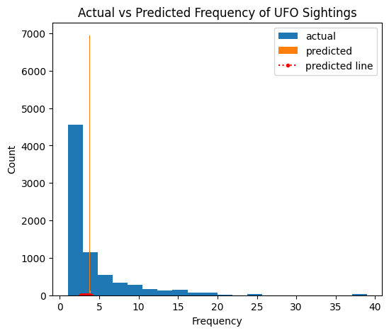

```python
# plot the actual vs predicted values for the model
plt.figure(figsize=(6, 5))

# plot the histogram of actual and predicted values
plt.hist(y_test, label="actual", bins=20)
plt.hist(y_pred, label="predicted", bins=20)

# create an array of x-coordinates for the line graph
x = np.linspace(min(y_pred), max(y_pred), len(y_pred))

# plot the predicted values as a line graph
plt.plot(x, y_pred, color="r", marker=".", linestyle=":", label="predicted line")

# set title and formatting
plt.title("Actual vs Predicted Frequency of UFO Sightings")
plt.legend(loc="upper right")
plt.xlabel("Frequency")
plt.ylabel("Count")
plt.savefig("plots/sgd_freq_plot.png")
plt.show()
```

```python
#actual
```

```python
# create a list of regression models to compare
models = [LinearRegression(fit_intercept=True, positive=True),
          Lasso(random_state=42),
          DecisionTreeRegressor(max_depth=5, criterion="poisson", random_state=42),
          RandomForestRegressor(n_estimators=200, max_features="sqrt", min_samples_split=4, random_state=42),
          SGDRegressor(loss="huber", penalty="elasticnet", l1_ratio=0.5, max_iter=1000,
                       epsilon=0.1592, learning_rate = "optimal", alpha=0.1)]
# define the cross-validation method to use
cv = KFold(n_splits=5, random_state=42, shuffle=True)

# define the scoring metrics to use
scoring = ["r2", "neg_mean_squared_error", "neg_mean_absolute_error"]

# make a dictionary to hold metric data
metric_data = {"model": ["LinearRegression", "Lasso", "DecisionTreeReg", "RandForestReg", "SGDReg"],
        "neg_mean_mse": [None, None, None, None, None],
        "neg_mean_mae": [None, None, None, None, None],
        "R2_mean": [None, None, None, None, None]}

# make a metric dataframe from metric_data
metric_df = pd.DataFrame(metric_data)

# loop through the models and compare their performance
for i, model in enumerate(models):
    # use cross_validate function to evaluate the model
    scores = cross_validate(model, X, y, scoring=scoring, cv=cv, n_jobs=-1)
    # store the metrics in the metric_df columns
    metric_df.loc[i, "neg_mean_mse"] = -round(scores["test_neg_mean_squared_error"].mean(), 2)
    metric_df.loc[i, "neg_mean_mae"] = -round(scores["test_neg_mean_absolute_error"].mean(), 2)
    metric_df.loc[i, "R2_mean"] = round(scores["test_r2"].mean(), 2)

    # print the model name and the mean test scores for each metric
    print(model.__class__.__name__, "\nneg_mean_squared_error: ", -scores["test_neg_mean_squared_error"].mean(), "\nneg_mean_absolute_error: ", -scores["test_neg_mean_absolute_error"].mean(), "\nr2: ", scores["test_r2"].mean())

#metric_df
```

```
LinearRegression
neg_mean_squared_error:  53.24772449103866
neg_mean_absolute_error:  4.363716499145674
r2:  0.026416819493444987
Lasso
neg_mean_squared_error:  53.255538314933105
neg_mean_absolute_error:  4.365752017361953
r2:  0.026273175714617136
DecisionTreeRegressor
neg_mean_squared_error:  48.24570551345131
neg_mean_absolute_error:  4.113791701573384
r2:  0.11781886444590403
RandomForestRegressor
neg_mean_squared_error:  2.07669204230165
neg_mean_absolute_error:  0.5949973316263848
r2:  0.962040558443084
SGDRegressor
neg_mean_squared_error:  61.973790588094815
neg_mean_absolute_error:  3.8750875792604518
r2:  -0.1342076760286101
```

```python
metric_df.to_csv("data/reg_models_metrics.csv")
print(metric_df)
```

```
              model neg_mean_mse neg_mean_mae R2_mean
0  LinearRegression        53.25         4.36    0.03
1             Lasso        53.26         4.37    0.03
2   DecisionTreeReg        48.25         4.11    0.12
3     RandForestReg         2.08         0.59    0.96
4            SGDReg        61.97         3.88   -0.13
```

# Project Goal #2: How well are the ML models able to predict the frequency of UFO sightings?

- Timeseries models: Prophet (from fbprophet) and Naive (from statsforecast)
- SciKit Learn's models: Linear Regression, Lasso Regressor, Decision Tree Regressor, Random Forest Regressor, and Stochastic Gradient Descent Regressor

```
## Frequency =  grouped by year, city, country and counting each group's size
## Probability = frequency / sum of all frequencies  (freq divided by sum of all freqs)
## Percent prob = prob. multiply by 100
```

```python
# create a dataframe to display predictions of each model
# make data as a dictionary of each model's prediction values
data = {"lr_pred": lr_pred.ravel(), "ls_pred": ls_pred.ravel(), "dt_pred": dt_pred.ravel(), "rf_pred": rf_pred.ravel(), "sgd_pred": sgd_pred.ravel(), "actual": actual.to_numpy().ravel()}
# make the column names as the names of models' prediction variables
columns = ["lr_pred", "ls_pred", "dt_pred", "rf_pred", "sgd_pred", "actual"]
preds_df = pd.DataFrame(data=data, columns=columns)
preds_df
```

|  | lr_pred | ls_pred | dt_pred | rf_pred | sgd_pred | actual |
| --- | --- | --- | --- | --- | --- | --- |
| 0 | 6.969984 | 6.861219 | 7.287624 | 5.940357 | 3.820596 | 2.0 |
| 1 | 5.809075 | 5.701624 | 4.445915 | 2.989333 | 3.820596 | 2.0 |
| 2 | 6.708229 | 6.599760 | 7.287624 | 1.302167 | 3.820596 | 2.0 |
| 3 | 6.632466 | 6.524083 | 7.287624 | 32.000000 | 3.820596 | 15.0 |
| 4 | 6.737250 | 6.628748 | 7.287624 | 3.898417 | 3.820596 | 5.0 |
| ... | ... | ... | ... | ... | ... | ... |
| 7527 | 3.385912 | 3.315122 | 2.585699 | 1.040000 | 2.800567 | 1.0 |
| 7528 | 5.836002 | 5.720797 | 5.770957 | 11.000000 | 3.821993 | 20.0 |
| 7529 | 5.795226 | 5.687480 | 1.339416 | 1.370917 | 3.640148 | 3.0 |
| 7530 | 6.592572 | 6.476511 | 7.287624 | 3.951250 | 3.821993 | 4.0 |
| 7531 | 5.601937 | 5.485892 | 2.317365 | 1.199970 | 3.849077 | 1.0 |

7532 rows × 6 columns

```python
# calculate prob and percent_prob of best scoring model RandomForestRegressor model
# calculate the actual probabilities of the actual frequency values
preds_df["act_prob"] = preds_df["actual"] / sum_freq  # using sum_freq, which was made long ago when freq calculations done
# calculate the predicted probabilities of the RandomForestRegressor model
preds_df["rf_pred_prob"] = preds_df["rf_pred"] / sum_freq
# calculate the predicted percent_prob of the RandomForestRegressor model
preds_df["rf_pred_percent_prob"] = preds_df["rf_pred_prob"] * 100
preds_df
```

|  | lr_pred | ls_pred | dt_pred | rf_pred | sgd_pred | actual | act_prob | rf_pred_prob | rf_pred_percent_prob |
| --- | --- | --- | --- | --- | --- | --- | --- | --- | --- |
| 0 | 6.969984 | 6.861219 | 7.287624 | 5.940357 | 3.820596 | 2.0 | 0.000003 | 0.000009 | 0.000905 |
| 1 | 5.809075 | 5.701624 | 4.445915 | 2.989333 | 3.820596 | 2.0 | 0.000003 | 0.000005 | 0.000455 |
| 2 | 6.708229 | 6.599760 | 7.287624 | 1.302167 | 3.820596 | 2.0 | 0.000003 | 0.000002 | 0.000198 |
| 3 | 6.632466 | 6.524083 | 7.287624 | 32.000000 | 3.820596 | 15.0 | 0.000023 | 0.000049 | 0.004874 |
| 4 | 6.737250 | 6.628748 | 7.287624 | 3.898417 | 3.820596 | 5.0 | 0.000008 | 0.000006 | 0.000594 |
| ... | ... | ... | ... | ... | ... | ... | ... | ... | ... |
| 7527 | 3.385912 | 3.315122 | 2.585699 | 1.040000 | 2.800567 | 1.0 | 0.000002 | 0.000002 | 0.000158 |
| 7528 | 5.836002 | 5.720797 | 5.770957 | 11.000000 | 3.821993 | 20.0 | 0.000030 | 0.000017 | 0.001676 |
| 7529 | 5.795226 | 5.687480 | 1.339416 | 1.370917 | 3.640148 | 3.0 | 0.000005 | 0.000002 | 0.000209 |
| 7530 | 6.592572 | 6.476511 | 7.287624 | 3.951250 | 3.821993 | 4.0 | 0.000006 | 0.000006 | 0.000602 |
| 7531 | 5.601937 | 5.485892 | 2.317365 | 1.199970 | 3.849077 | 1.0 | 0.000002 | 0.000002 | 0.000183 |

7532 rows × 9 columns

```python
# subset the ufo_reset_df dataframe to features that will help in interpreting predictions
preds_cities = ufo_reset_df[["date_time","year","city","state","country","city_latitude","city_longitude","freq","prob","percent_prob"]]
# reset the index numbering of preds_cities
preds_cities = preds_cities.reset_index(drop=True)
# filter out years that are not in the target set
preds_cities = preds_cities.loc[preds_cities["year"] > 2020]
preds_cities
```

|  | date_time | year | city | state | country | city_latitude | city_longitude | freq | prob | percent_prob |
| --- | --- | --- | --- | --- | --- | --- | --- | --- | --- | --- |
| 131883 | 2021-01-01 00:00:00 | 2021 | Tempe | AZ | USA | 33.397445 | -111.924685 | 2.0 | 0.000003 | 0.0003 |
| 131884 | 2021-01-01 00:00:00 | 2021 | Deltona | FL | USA | 28.904056 | -81.238074 | 2.0 | 0.000003 | 0.0003 |
| 131885 | 2021-01-01 00:00:00 | 2021 | Rapid City | SD | USA | 44.072001 | -103.255555 | 2.0 | 0.000003 | 0.0003 |
| 131886 | 2021-01-01 00:00:00 | 2021 | Phoenix | AZ | USA | 33.503786 | -112.077080 | 15.0 | 0.000023 | 0.0023 |
| 131887 | 2021-01-01 00:00:00 | 2021 | Riverview | FL | USA | 27.848577 | -82.321746 | 5.0 | 0.000008 | 0.0008 |
| ... | ... | ... | ... | ... | ... | ... | ... | ... | ... | ... |
| 139669 | 2022-12-21 21:33:00 | 2022 | Columbus | OH | USA | 39.993828 | -82.982484 | 20.0 | 0.000030 | 0.0030 |
| 139670 | 2022-12-22 00:00:00 | 2022 | NaN | NC | USA | NaN | NaN | NaN | NaN | NaN |
| 139671 | 2022-12-22 00:00:00 | 2022 | Johannesburg | GAUTENG | South Africa | NaN | NaN | 3.0 | 0.000005 | 0.0005 |
| 139672 | 2022-12-22 09:29:00 | 2022 | Newark | DE | USA | 39.670280 | -75.720711 | 4.0 | 0.000006 | 0.0006 |
| 139673 | 2022-12-22 10:50:00 | 2022 | Ahmedabad | nan | Unknown | NaN | NaN | 1.0 | 0.000002 | 0.0002 |

7791 rows × 10 columns

```python
# filter out the missing values from city and state columns with a mask
# set mask to cities that are NA
mask = preds_cities["city"].isna()
# assign preds_cities to the cities that are not NA with inverse operator
preds_cities = preds_cities[~mask]
# set mask to states that are NA
mask = preds_cities["state"].isna()
# assign preds_cities to the states that are not NA with inverse operator
preds_cities = preds_cities[~mask]
preds_cities
```

|  | date_time | year | city | state | country | city_latitude | city_longitude | freq | prob | percent_prob |
| --- | --- | --- | --- | --- | --- | --- | --- | --- | --- | --- |
| 131883 | 2021-01-01 00:00:00 | 2021 | Tempe | AZ | USA | 33.397445 | -111.924685 | 2.0 | 0.000003 | 0.0003 |
| 131884 | 2021-01-01 00:00:00 | 2021 | Deltona | FL | USA | 28.904056 | -81.238074 | 2.0 | 0.000003 | 0.0003 |
| 131885 | 2021-01-01 00:00:00 | 2021 | Rapid City | SD | USA | 44.072001 | -103.255555 | 2.0 | 0.000003 | 0.0003 |
| 131886 | 2021-01-01 00:00:00 | 2021 | Phoenix | AZ | USA | 33.503786 | -112.077080 | 15.0 | 0.000023 | 0.0023 |
| 131887 | 2021-01-01 00:00:00 | 2021 | Riverview | FL | USA | 27.848577 | -82.321746 | 5.0 | 0.000008 | 0.0008 |
| ... | ... | ... | ... | ... | ... | ... | ... | ... | ... | ... |
| 139667 | 2022-12-21 07:55:00 | 2022 | Essex | ON | Canada | 42.173600 | -82.829900 | 1.0 | 0.000002 | 0.0002 |
| 139669 | 2022-12-21 21:33:00 | 2022 | Columbus | OH | USA | 39.993828 | -82.982484 | 20.0 | 0.000030 | 0.0030 |
| 139671 | 2022-12-22 00:00:00 | 2022 | Johannesburg | GAUTENG | South Africa | NaN | NaN | 3.0 | 0.000005 | 0.0005 |
| 139672 | 2022-12-22 09:29:00 | 2022 | Newark | DE | USA | 39.670280 | -75.720711 | 4.0 | 0.000006 | 0.0006 |
| 139673 | 2022-12-22 10:50:00 | 2022 | Ahmedabad | nan | Unknown | NaN | NaN | 1.0 | 0.000002 | 0.0002 |

7532 rows × 10 columns

```python
# assign important features or columns of preds_df to preds_cities
preds_cities["actual"] = preds_df["actual"].values
preds_cities["act_prob"] = preds_df["act_prob"].values
preds_cities["rf_pred"] = preds_df["rf_pred"].values
preds_cities["rf_pred_prob"] = preds_df["rf_pred_prob"].values
preds_cities["rf_pred_percent_prob"] = preds_df["rf_pred_percent_prob"].values
#preds_cities
```

```python
# checking to see if freq values from preds_cities["freq"] is equal to preds_cities["actual"]
flag = 0
# if any of the freq values are not equal, flag would be 1
if not (preds_cities["freq"] == preds_cities["actual"]).any():
    flag += 1
print(flag)
```

```
0
```

```python
# Drop columns in place
#df.drop(columns=['gender', 'salary'], inplace=True)
preds_cities.drop(columns=["actual","act_prob"], inplace=True)
preds_cities
```

|  | date_time | year | city | state | country | city_latitude | city_longitude | freq | prob | percent_prob | rf_pred | rf_pred_prob | rf_pred_percent_prob |
| --- | --- | --- | --- | --- | --- | --- | --- | --- | --- | --- | --- | --- | --- |
| 131883 | 2021-01-01 00:00:00 | 2021 | Tempe | AZ | USA | 33.397445 | -111.924685 | 2.0 | 0.000003 | 0.0003 | 5.940357 | 0.000009 | 0.000905 |
| 131884 | 2021-01-01 00:00:00 | 2021 | Deltona | FL | USA | 28.904056 | -81.238074 | 2.0 | 0.000003 | 0.0003 | 2.989333 | 0.000005 | 0.000455 |
| 131885 | 2021-01-01 00:00:00 | 2021 | Rapid City | SD | USA | 44.072001 | -103.255555 | 2.0 | 0.000003 | 0.0003 | 1.302167 | 0.000002 | 0.000198 |
| 131886 | 2021-01-01 00:00:00 | 2021 | Phoenix | AZ | USA | 33.503786 | -112.077080 | 15.0 | 0.000023 | 0.0023 | 32.000000 | 0.000049 | 0.004874 |
| 131887 | 2021-01-01 00:00:00 | 2021 | Riverview | FL | USA | 27.848577 | -82.321746 | 5.0 | 0.000008 | 0.0008 | 3.898417 | 0.000006 | 0.000594 |
| ... | ... | ... | ... | ... | ... | ... | ... | ... | ... | ... | ... | ... | ... |
| 139667 | 2022-12-21 07:55:00 | 2022 | Essex | ON | Canada | 42.173600 | -82.829900 | 1.0 | 0.000002 | 0.0002 | 1.040000 | 0.000002 | 0.000158 |
| 139669 | 2022-12-21 21:33:00 | 2022 | Columbus | OH | USA | 39.993828 | -82.982484 | 20.0 | 0.000030 | 0.0030 | 11.000000 | 0.000017 | 0.001676 |
| 139671 | 2022-12-22 00:00:00 | 2022 | Johannesburg | GAUTENG | South Africa | NaN | NaN | 3.0 | 0.000005 | 0.0005 | 1.370917 | 0.000002 | 0.000209 |
| 139672 | 2022-12-22 09:29:00 | 2022 | Newark | DE | USA | 39.670280 | -75.720711 | 4.0 | 0.000006 | 0.0006 | 3.951250 | 0.000006 | 0.000602 |
| 139673 | 2022-12-22 10:50:00 | 2022 | Ahmedabad | nan | Unknown | NaN | NaN | 1.0 | 0.000002 | 0.0002 | 1.199970 | 0.000002 | 0.000183 |

7532 rows × 13 columns

```python
# save preds_cities dataframe as a csv file
preds_cities.to_csv("data/preds_cities_data.csv")
```

# Create a Map with Highest Actual & Predicted Frequencies & Probabilities

```python
# make a bar chart for highest frequencies and probabilities in a year, city and country

# get the top prob values
high_prob = preds_cities.groupby(["year","city","state","country","city_latitude","city_longitude","freq","percent_prob","rf_pred","rf_pred_percent_prob"]).size()
# sort in descending order
high_prob = high_prob.sort_values(ascending=False)
# get the top freq values
high_prob = high_prob.head(100)
# reset the index to count to get a dataframe
high_prob = high_prob.reset_index(name="count")

print("Cities with Highest Actual vs Predicted Frequencies & Probabilities of UFO Sightings")
# create a folium map object with Wichita's as the location view
map = folium.Map(location=[38, -97], zoom_start=4)

# add a marker for each city with a popup showing its name and percent probabilty
for i, row in high_prob.iterrows():
    folium.Marker(
        location=[row["city_latitude"], row["city_longitude"]],
        popup=f"{row['city']}, {row['state']} ({row['year']})<br>actual_%prob={row['percent_prob']}%<br>actual_freq={row['freq']}<br>pred_%prob={round(row['rf_pred_percent_prob'],4)}%<br>pred_freq={row['rf_pred']}",
        tooltip=f"{row['city']} {row['year']}<br>{row['percent_prob']}%"
    ).add_to(map)

# Save and display the map
map.save("maps/top_cities_freq_map.html")
map
```

```
Cities with Highest Actual vs Predicted Frequencies & Probabilities of UFO Sightings
```

[interactive chart not shown]

```python
#preds_df.loc[preds_df["city"] == "Phoenix"]
```

# Part II. Supplemental Questions

# Supplemental Question: Compare Years with Number of UFO Sightings (WITH and WITHOUT hoax filter)

```python
# extract the year from the date_time column
compare_df = ufo_df.copy()  # Need to make copy of ufo_df of possibility of altering the working dataframe
compare_df["year"] = pd.DatetimeIndex(compare_df["date_time"]).year
compare_df2 = ufo_df.copy()
compare_df2["year"] = pd.DatetimeIndex(compare_df2["date_time"]).year

# create a list of years for comparison
yr_list = [1762, 1860, 1861, 1864, 1865, 1925, 1928, 1929, 1930, 1931, 1932, 1936, 1940, 1945, 1950, 1955, 1960, 1965, 1970, 1975, 1980, 1985, 1990, 1995, 2000, 2005, 2010, 2011, 2012, 2013, 2014, 2015, 2016, 2017, 2018, 2019, 2020, 2021, 2022]
recent_yr_list = [1960,1970,1971,1972,1973,1974,1975,1976,1977,1978,1979,1980,1981,1982,1983,1984,1985,1987,1988,1989,1990,1991,1992,1993,1994,1995,1996,1997,1998,1999,2000,2001,2002,2003,2004,2005,2006,2007,2008,2009,2010,2011,2012,2013,2014,2015,2016,2017,2018,2019,2020,2021,2022]

# filter the dataframe by the given years
compare_df_allyrs = compare_df.copy()   # To make distribution graphs later
compare_df = compare_df.loc[compare_df["year"].isin(yr_list)]
compare_df2 = compare_df2.loc[compare_df2["year"].isin(recent_yr_list)]

# group by year and count sightings
all_yrs = compare_df_allyrs.groupby("year").size()
yrs_comp = compare_df.groupby("year").size()
recent_yrs_comp = compare_df2.groupby("year").size()

# reset index to count
all_yrs = all_yrs.reset_index(name="count")
yrs_comp = yrs_comp.reset_index(name="count")
recent_yrs_comp = recent_yrs_comp.reset_index(name="count")

print("Year and Counts of UFO Sightings (hoax filtered)\n", yrs_comp.head(10).astype(int).to_string(index=True))
print("\nYear and Counts of UFO Sightings (no hoax filter)\n", yrs_comp_no_fil.head(10).astype(int).to_string(index=True))
print("\nRecent Year and Counts of UFO Sightings (hoax filtered)\n", recent_yrs_comp.tail(10).astype(int).to_string(index=True))
print("\nRecent Year and Counts of UFO Sightings (no hoax filter)\n", recent_yrs_comp_no_fil.tail(10).astype(int).to_string(index=True))
```

```
Year and Counts of UFO Sightings (hoax filtered)
    year  count
0  1762      1
1  1860      1
2  1861      1
3  1864      2
4  1865      1
5  1925      1
6  1928      1
7  1929      2
8  1930      5
9  1931      2

Year and Counts of UFO Sightings (no hoax filter)
    year  count
```

[output cut: 36 more lines]

## Line Graphs and Bar Charts of Counts by Year of UFO sightings

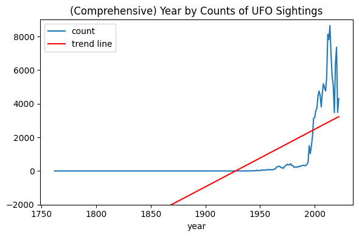

```python
# plot trend line and line graph of all years by count
# make a line graph of ALL years by count
all_yrs.plot(x="year", y="count", kind="line", legend=True)

# get x and y values to plot trend line
x = all_yrs["year"]
y = all_yrs["count"]
z = np.polyfit(x,y,1)  # set degree as one for linear graph
p = np.poly1d(z)       # create a polynomial object

# plot the trend line
plt.plot(x, p(x), color="red", label="trend line")
plt.title("(Comprehensive) Year by Counts of UFO Sightings")
plt.legend()
plt.ylim(-2000, 9000)
plt.tight_layout()
# save as png file
plt.savefig("plots/all_years_trend_line.png")
plt.show()
```

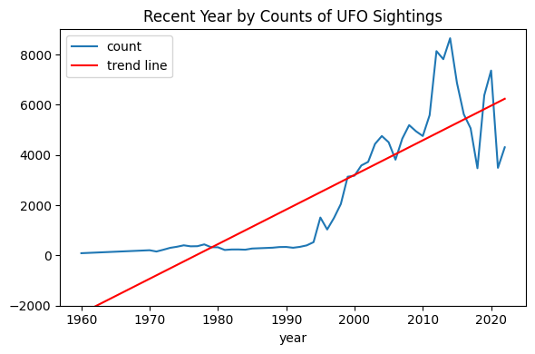

```python
# plot trend line and line graph of recent years by count
# make a line graph of year by count in recent_yr_list
recent_yrs_comp.plot(x="year", y="count", kind="line", legend=True)

# get x and y values to plot trend line
x = recent_yrs_comp["year"]
y = recent_yrs_comp["count"]
z = np.polyfit(x,y,1)  # set degree as one for linear graph
p = np.poly1d(z)       # create a polynomial object

# plot the trend line
plt.plot(x, p(x), color="red", label="trend line")
plt.title("Recent Year by Counts of UFO Sightings")
plt.legend()
plt.ylim(-2000, 9000)
plt.tight_layout()
# save as png file
plt.savefig("plots/recent_years_trend_line.png")
plt.show()
```

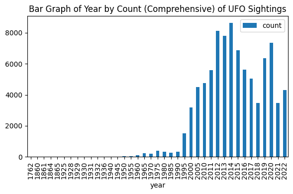

```python
# make a bar graph of year by count
yrs_comp.plot(x="year", y="count", kind="bar")
plt.title("Bar Graph of Year by Count (Comprehensive) of UFO Sightings")
plt.tight_layout()
plt.show()
```

```python
# testing
#len(recent_yr_list)

# verify year count with selection of the dataframe and shape function
compare_df = ufo_df.copy()
compare_df["year"] = pd.DatetimeIndex(compare_df["date_time"]).year
compare_df.loc[compare_df["year"] == 1970].shape[0]

# verify year count with selection of the dataframe and shape function
compare_df["year"] = pd.DatetimeIndex(compare_df["date_time"]).year
compare_df.loc[compare_df["year"] == 2013].shape[0]
```

```
7812
```

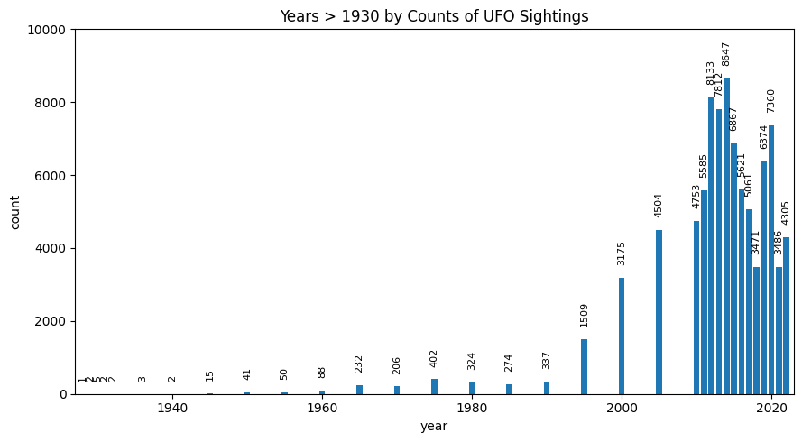

```python
# make bar graph for years > 1930 and counts
fig, ax = plt.subplots(figsize=(9,5))

# get x and y values from yrs_comp dataframe
x = yrs_comp["year"]
y = yrs_comp["count"]

# make a bar plot with the x and y values
bar_container = ax.bar(x, y)
# set the labels and title
ax.set(xlabel="year", ylabel='count', title="Years > 1930 by Counts of UFO Sightings")
# format the bar_label object
ax.bar_label(bar_container, fontsize=8, rotation=90, padding=10)
#plt.xticks(yr_list[:7],yr_list[:7])
plt.xlim(1927,2023)  # set the x-axis limit
plt.ylim(0,10000)    # set the y-axis limit
plt.tight_layout()
plt.show()
```

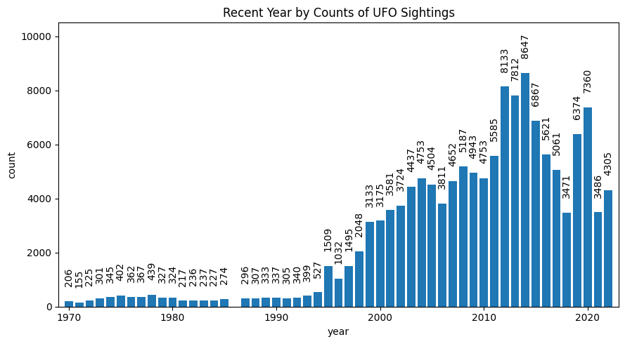

```python
# make bar graph for recent years (1970 and on) and counts
fig, ax = plt.subplots(figsize=(9,5))

# get x and y values from yrs_comp dataframe
x = recent_yrs_comp["year"]
y = recent_yrs_comp["count"]
# make a bar plot with the x and y values
bar_container = ax.bar(x, y)
# set the labels and title
ax.set(xlabel="year", ylabel='count', title="Recent Year by Counts of UFO Sightings", ylim=(0, 9500))
# format the bar_label object
ax.bar_label(bar_container, fontsize=10, rotation=90, padding=15)
plt.xlim(1969, 2023) # set the x-axis limit
plt.ylim(0, 10500)   # set the y-axis limit
plt.tight_layout()
# save as png file
plt.savefig("plots/recent_years_barplot.png")
plt.show()
```

# Supplemental Question: What are the years with the highest counts of UFO sightings?

```
Years with Highest Counts of UFO Sightings
  year  count
 2014   8647
 2012   8133
 2013   7812
 2020   7360
 2015   6867
 2019   6374
 2016   5621
 2011   5585
 2008   5187
 2017   5061
 2009   4943
 2010   4753
 2004   4753
 2007   4652
 2005   4504
```

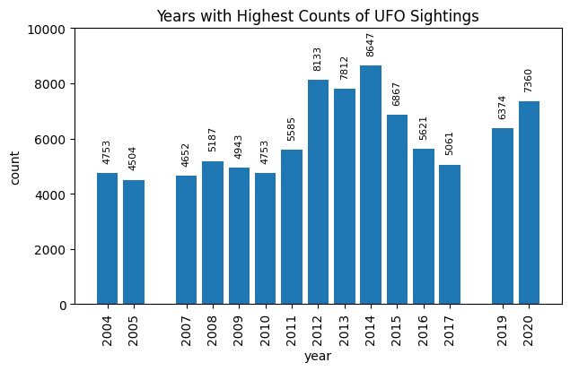

```python
# copy of ufo_df to compare_df
compare_df = ufo_df.copy()

# convert the date_time column to datetime format
compare_df["date_time"] = pd.to_datetime(compare_df["date_time"])
# extract the year from the date_time column and store it in a new column
compare_df["year"] = compare_df["date_time"].dt.year
# group by year and count the number of sightings
top_years = compare_df.groupby("year").size()

# sort the series in descending order and select the top years
top_years = top_years.sort_values(ascending=False).head(15)
# reset the index of top_years to count
top_years = top_years.reset_index(name="count")
#top_years = top_years.astype(int)

# print the years with count table
print("Years with Highest Counts of UFO Sightings\n", top_years.to_string(index=False))

# make bar graph with subplot size formatting
fig, ax = plt.subplots(figsize=(7,4))

# assign years to x for bar values
x = top_years["year"]
# assign count to y
y = top_years["count"]

# make a bar chart with the x and y values
# subtract 0.4 from x values
bar_container = ax.bar(x, y)

# set the labels and title
ax.set(xlabel="year", ylabel="count", title="Years with Highest Counts of UFO Sightings")
# format the bar_label object
ax.bar_label(bar_container, fontsize=8, rotation=90, padding=8)
# set the xticks and xticklabels
plt.xticks(x, top_years["year"], rotation=90,)
plt.ylim(0, 10000)   # set the y-axis limit
# save as png file
plt.savefig("plots/top_years_barplot.png")
plt.show()
```

# Supplemental Question: The Top 4 Months with the Highest Counts of UFO Sightings

```python
# get the month from the date_time column
compare_df = ufo_df.copy()
compare_df["month"] = pd.DatetimeIndex(compare_df["date_time"]).month

# group by month and count sightings
sightings = compare_df.groupby("month").size()

# sort by count in descending order
sightings = sightings.sort_values(ascending=False)

# select the first 4 rows
sightings = sightings.head(4)

# reset index to get a dataframe
sightings = sightings.reset_index(name="count")

print("Top 4 Months with Highest Counts of UFO Sightings\n", sightings.astype(int).to_string(index=False))
```

```
Top 4 Months with Highest Counts of UFO Sightings
  month  count
     7  16302
     8  14607
     6  13710
     9  13417
```

## Bar Chart for the Counts by Month of UFO sightings

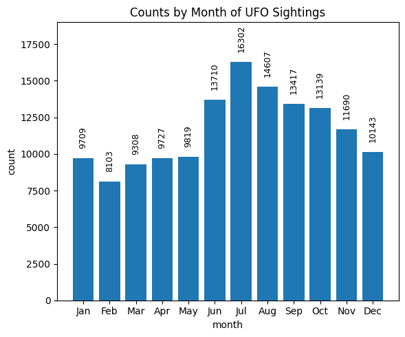

```python
# plot a bar chart for the counts by month of UFO sightings
compare_df = ufo_df.copy()

# get the month from the date_time column
compare_df["month"] = pd.DatetimeIndex(compare_df["date_time"]).month

# make a bar graph of count of sightings by month
month_count = compare_df.groupby("month").size()
# reset the index to count to get a dataframe
month_count = month_count.reset_index(name="count")

# make a month list for xticks markers
months = ["Jan", "Feb", "Mar", "Apr", "May", "Jun", "Jul", "Aug", "Sep", "Oct", "Nov", "Dec"]

# make bar graph with subplot size formatting
fig, ax = plt.subplots(figsize=(6,5))

# get x and y values from yrs_comp dataframe
x = month_count["month"]
y = month_count["count"]

# make a bar chart with the x and y values
bar_container = ax.bar(x, y)
# set the labels and title
ax.set(xlabel="month", ylabel="count", title="Counts by Month of UFO Sightings")
# format the bar_label object
ax.bar_label(bar_container, fontsize=9, rotation=90, padding=10)
# set the xticks and xticklabels
plt.xticks(range(1, 13), months)
plt.ylim(0, 19000)   # set the y-axis limit
plt.tight_layout()
# Save the figure as a PNG file named 'line_plot.png' in your current directory
plt.savefig('month_barplot.png')
plt.show()
```

```python
# testing
# Verify month count with selection of the dataframe and shape function
compare_df["month"] = pd.DatetimeIndex(compare_df["date_time"]).month
compare_df.loc[compare_df["month"] == 7].shape[0]

# Verify month count with selection of the dataframe and shape function
#compare_df["month"] = pd.DatetimeIndex(compare_df["date_time"]).month
#compare_df.loc[compare_df["month"] == 9].shape[0]
```

```
16302
```

# Supplemental Question: Top 10 (Non-USA) Cities, States, Countries, and Locations with Highest Counts

```python
compare_df = ufo_df.copy()  # Need to make copy of ufo_df because this block may alter the actual dataframe
# filter the dataframe by country not equal to USA
compare_df = compare_df.loc[compare_df["country"] != "USA"]

# group by city, state, and location; count sightings for each group
sightings = compare_df.groupby("city").size()
sightings2 = compare_df.groupby("state").size()
sightings3 = compare_df.groupby("country").size()

# sort by counts in descending order
sightings = sightings.sort_values(ascending=False)
sightings2 = sightings2.sort_values(ascending=False)
sightings3 = sightings3.sort_values(ascending=False)

# select top 10 values
sightings = sightings.head(n=10)
sightings2 = sightings2.head(n=10)
sightings3 = sightings3.head(n=10)

# reset index to get a dataframe
sightings = sightings.reset_index(name="count")
sightings2 = sightings2.reset_index(name="count")
sightings3 = sightings3.reset_index(name="count")

# add 1 to the new index to make list start at 1
sightings.index = sightings.index + 1
sightings2.index = sightings2.index + 1
sightings3.index = sightings3.index + 1

# print the result
print("Top 10  (Non-USA) Cities with Highest Numbers of Sightings\n", sightings)
print("\nTop 10 (Non-USA) States with Highest Numbers of Sightings\n", sightings2)
print("\nTop 10  (Non-USA) Countries with Highest Numbers of Sightings\n",sightings3)
```

```
Top 10  (Non-USA) Cities with Highest Numbers of Sightings
           city  count
1       London    326
2      Toronto    265
3      Calgary    146
4    Vancouver    136
5       Ottawa    132
6     Edmonton    129
7     Winnipeg    106
8     Victoria    104
9     Montreal    104
10  Manchester     83

Top 10 (Non-USA) States with Highest Numbers of Sightings
       state  count
```

[output cut: 23 more lines]

# Supplemental Question: Top 10 Countries with Highest Counts and Graphs

```python
compare_df = ufo_df.copy()  # Need to make copy of ufo_df because this block may alter the actual dataframe
# group by country
top_countries = compare_df.groupby("country").size()
# sort in descending order
top_countries = top_countries.sort_values(ascending=False)
# reset the index to count to get a dataframe
top_countries = top_countries.reset_index(name="count")
# add 1 to the index so list starts at 1
top_countries.index = top_countries.index + 1

print("Top Countries with Highest Counts of UFO Sightings\n", top_countries.head(10))
```

```
Top Countries with Highest Counts of UFO Sightings
            country   count
1              USA  124633
2           Canada    5649
3        Australia     867
4            India     439
5           Mexico     387
6   United Kingdom     236
7      New Zealand     195
8          Germany     193
9     South Africa     193
10     Puerto Rico     181
```

## Line Graph/Bar Chart of Countries by Counts of UFO sightings

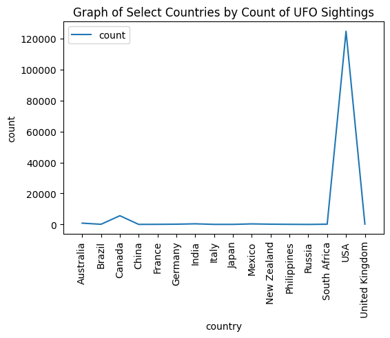

```python
compare_df = ufo_df.copy()  # Need to make copy of ufo_df because this block may alter the actual dataframe

# create a list of countries
countries = ["Japan", "Russia", "USA", "Australia", "New Zealand", "Brazil", "Canada", "China", "France", "Germany", "India", "Italy", "Mexico", "Philippines", "South Africa", "United Kingdom"]
# sort the countries list
countries.sort()
# filter by countries list
top_countries = compare_df.loc[compare_df["country"].isin(countries)]
# group by country and get the size
top_countries = top_countries.groupby("country").size()
# reset index to count
top_countries = top_countries.reset_index(name="count")

# plot the graph and set to appropriate format and labels
top_countries.plot(x="country", xlabel="country", y="count", ylabel="count", rot=90, kind="line", legend=True)
plt.title("Graph of Select Countries by Count of UFO Sightings")
plt.legend()
plt.xticks(range(0, 16), countries)   # set the xticks and xticklabels
plt.xlim(-1,16)
plt.show()
```

```
Countries with Highest Counts of UFO Sightings
            country   count
1              USA  124633
2           Canada    5649
3        Australia     867
4            India     439
5           Mexico     387
6   United Kingdom     236
7      New Zealand     195
8          Germany     193
9     South Africa     193
10     Puerto Rico     181
```

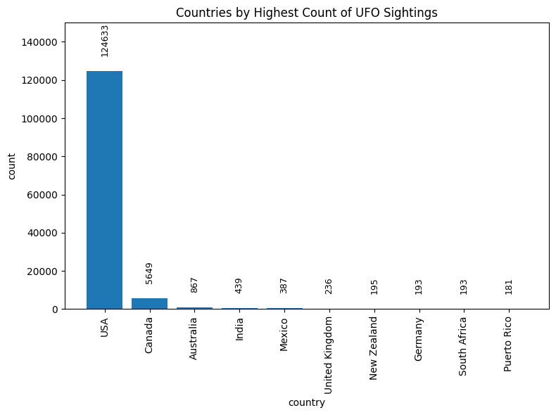

```python
# Bar graph of top countries by highest count
compare_df = ufo_df.copy()  # Need to make copy of ufo_df because this block may alter the actual dataframe
# group by country
top_countries = compare_df.groupby("country").size()
# sort in descending order
top_countries = top_countries.sort_values(ascending=False)
# get the top countries values
top_countries = top_countries.head(10)

# reset the index to count to get a dataframe
top_countries = top_countries.reset_index(name="count")
# add 1 to the index so list starts at 1
top_countries.index = top_countries.index + 1

print("Countries with Highest Counts of UFO Sightings\n", top_countries)

# make fig and ax objects with subplot size formatting
fig, ax = plt.subplots(figsize=(8,6))

# get x and y values from yrs_comp dataframe
x = top_countries["country"]
y = top_countries["count"]

# make a bar chart with the x and y values
bar_container = ax.bar(x, y)
# set the labels and title
ax.set(xlabel="country", ylabel="count", title="Countries by Highest Count of UFO Sightings")
# format the bar_label object
ax.bar_label(bar_container, fontsize=9, rotation=90, padding=15)
# set the xticks and xticklabels
plt.xticks(range(0, 10), top_countries["country"], rotation=90)
# set the y-axis limit
plt.ylim(0, 150000)
plt.tight_layout()
plt.show()
```

# Supplemental Question: Compare Top 10 Locations (All Countries) with the Highest Frequency Counts of UFO Sightings

```python
# copy ufo_df because this block may alter the actual dataframe
compare_df = ufo_reset_df.copy()
# group by location and count sightings
sightings_city = compare_df.groupby(["city","freq"]).size()
sightings_st = compare_df.groupby(["state","freq"]).size()
sightings_ctry = compare_df.groupby(["country","freq"]).size()

# sort by count in descending order
sightings_city = sightings_city.sort_values(ascending=False)
sightings_st = sightings_st.sort_values(ascending=False)
sightings_ctry = sightings_ctry.sort_values(ascending=False)

# select the first 10 rows
sightings_city = sightings_city.head(10)
sightings_st = sightings_st.head(10)
sightings_ctry = sightings_ctry.head(10)

# reset index to get a dataframe
sightings_city = sightings_city.reset_index(name='count')
sightings_st = sightings_st.reset_index(name='count')
sightings_ctry = sightings_ctry.reset_index(name='count')
sightings_ctry_no_fil.index = sightings_ctry_no_fil.index + 1
sightings_ctry.index = sightings_ctry.index + 1

# print the results of sightings frequencies with locations
print("Top Cities of UFO Sightings with hoax filter\n", sightings_city)
print("\nTop States of UFO Sightings with hoax filter\n", sightings_st)
print("\nTop Countries of UFO Sightings with hoax filter\n", sightings_ctry)
```

```
Top Cities of UFO Sightings with hoax filter
           city  freq  count
0     Portland  35.0    105
1  Tinley Park  93.0     93
2      Phoenix  45.0     90
3      Phoenix  44.0     88
4     New York  41.0     82
5       Tucson  24.0     72
6     New York  34.0     68
7    Charlotte  13.0     65
8       Austin  13.0     65
9      Seattle  30.0     60

Top States of UFO Sightings with hoax filter
   state  freq  count
```

[output cut: 23 more lines]

# Supplemental Question: Compare Top 10 Locations (All Countries) with the Highest Counts of UFO Sightings WITHOUT and WITH hoax filter

### Note: One purpose of these comparison lists is to see if the hoax filter drastically changes the data. It does not seem to do much at all. The hoax-filtered lists have also had the datetime column fixed and that may change the year counts by a small margin.

```python
# copy ufo_df because this block may alter the actual dataframe
compare_df = ufo_df.copy()
# group by location and count sightings
sightings2 = compare_df.groupby(["city"]).size()
sightings3 = compare_df.groupby(["state"]).size()
sightings4 = compare_df.groupby(["country"]).size()

# sort by count in descending order
sightings2 = sightings2.sort_values(ascending=False)
sightings3 = sightings3.sort_values(ascending=False)
sightings4 = sightings4.sort_values(ascending=False)

# select the first 10 rows
sightings2 = sightings2.head(10)
sightings3 = sightings3.head(10)
sightings4 = sightings4.head(10)

# reset index to get a dataframe
sightings2 = sightings2.reset_index(name='count')
sightings3 = sightings3.reset_index(name='count')
sightings4 = sightings4.reset_index(name='count')
sightings_ctry_no_fil.index = sightings_ctry_no_fil.index + 1
sightings4.index = sightings4.index + 1

# print the results of sightings with and without hoax filter
print_list("Top Cities of UFO Sightings without hoax filter", "city", "count", sightings_no_fil) # from previous block above, before hoax filter application to dataframe
print_list("\nTop Cities of UFO Sightings with hoax filter", "city",  "count", sightings2)
print_sm_list("\nTop States of UFO Sightings without hoax filter", "state", "count", sightings_st_no_fil)
print_sm_list("\nTop States of UFO Sightings with hoax filter", "state",  "count", sightings3)
print("\nTop Countries of UFO Sightings without hoax filter\n", sightings_ctry_no_fil)
print("\nTop Countries of UFO Sightings with hoax filter\n", sightings4)
```

```
Top Cities of UFO Sightings without hoax filter
   city 		       count
1. New York		873
2. Phoenix		793
3. Seattle		783
4. Las Vegas		683
5. Portland		659
6. Los Angeles		578
7. San Diego		567
8. Houston		476
9. Chicago		453
10. Tucson		451

Top Cities of UFO Sightings with hoax filter
   city 		       count
1. New York		856
2. Phoenix		787
3. Seattle		780
4. Las Vegas		678
5. Portland		652
6. Los Angeles		576
7. San Diego		564
8. Houston		473
9. Chicago		450
10. Tucson		448

Top States of UFO Sightings without hoax filter
   state        count
1. CA		15454
2. FL		7823
3. WA		6895
4. nan		6267
5. TX		5816
6. NY		5624
7. PA		4780
8. AZ		4727
9. OH		4271
10. IL		4111

Top States of UFO Sightings with hoax filter
```

[output cut: 22 more lines]

```
11    South Africa     195
12     Puerto Rico     182

Top Countries of UFO Sightings with hoax filter
            country   count
1              USA  124633
2           Canada    5649
3        Australia     867
4            India     439
5           Mexico     387
6   United Kingdom     236
7      New Zealand     195
8          Germany     193
9     South Africa     193
10     Puerto Rico     181
```

# Supplemental Question: Compare Top 10 US Locations with the Highest Counts of UFO Sightings WITHOUT and WITH hoax filter

```python
# Need to make copy of ufo_df because this block may alter the actual dataframe
compare_df = ufo_df.copy()
# filter the dataframe by country equal to USA
compare_df = compare_df.loc[compare_df["country"] == "USA"]

# group by location and count sightings
sightings2 = compare_df.groupby(["city"]).size()
sightings3 = compare_df.groupby(["state"]).size()

# sort by count in descending order
sightings2 = sightings2.sort_values(ascending=False)
sightings3 = sightings3.sort_values(ascending=False)

# select the first 10 rows
sightings2 = sightings2.head(10)
sightings3 = sightings3.head(10)

# reset index to get a dataframe
sightings2 = sightings2.reset_index(name='count')
sightings3 = sightings3.reset_index(name='count')

# print the results of sightings with and without hoax filter
print_sm_list("Top US Cities of UFO Sightings without hoax filter", "city",  "count", sightings_us_no_fil)
print_sm_list("\nTop US Cities of UFO Sightings with hoax filter", "city",  "count", sightings2)
print_sm_list("\nTop US States with UFO Sightings without hoax filter", "state", "count", sightings_us_st_no_fil)
print_sm_list("\nTop US States of UFO Sightings with hoax filter", "state",  "count", sightings3)
```

```
Top US Cities of UFO Sightings without hoax filter
   city        count
1. New York		872
2. Phoenix		793
3. Seattle		783
4. Las Vegas		682
5. Portland		659
6. Los Angeles		578
7. San Diego		565
8. Chicago		452
9. Tucson		451
10. Houston		447

Top US Cities of UFO Sightings with hoax filter
   city        count
1. New York		856
2. Phoenix		787
3. Seattle		780
4. Las Vegas		677
5. Portland		652
6. Los Angeles		576
7. San Diego		562
8. Chicago		449
9. Tucson		448
10. Houston		444

Top US States with UFO Sightings without hoax filter
   state        count
1. CA		15446
2. FL		7815
3. WA		6893
4. TX		5813
5. NY		5619
6. PA		4775
7. AZ		4726
8. OH		4265
9. IL		4108
10. MI		3489

Top US States of UFO Sightings with hoax filter
   state        count
1. CA		15323
2. FL		7749
3. WA		6848
4. TX		5755
5. NY		5555
6. PA		4724
7. AZ		4690
8. OH		4214
9. IL		4057
10. NC		3452
```

# Supplemental Question: What US states have the most UFO sightings?

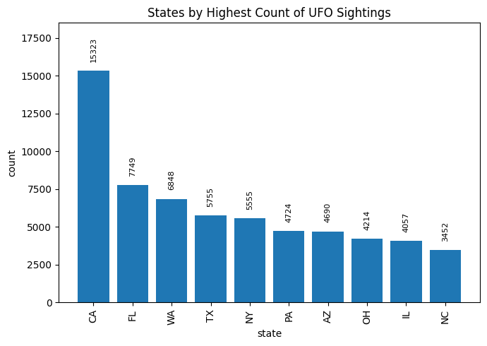

```python
# make copy of ufo_df
compare_df = ufo_df.copy()
# filter the dataframe by country equal to USA
compare_df = compare_df.loc[compare_df["country"] == "USA"]

# group by location and count sightings
sightings_st = compare_df.groupby(["state"]).size()
# sort by count in descending order
sightings_st = sightings_st.sort_values(ascending=False)
# select the first 10 rows
sightings_st = sightings_st.head(10)
# reset index to get a dataframe
sightings_st = sightings_st.reset_index(name='count')

# make fig and ax objects with subplot size formatting
fig, ax = plt.subplots(figsize=(7,5))

# get x and y values from yrs_comp dataframe
x = sightings_st["state"]
y = sightings_st["count"]

# make a bar chart with the x and y values
bar_container = ax.bar(x, y)
# set the labels and title
ax.set(xlabel="state", ylabel="count", title="States by Highest Count of UFO Sightings")
# format the bar_label object
ax.bar_label(bar_container, fontsize=8, rotation=90, padding=9)
# set the xticks and xticklabels
plt.xticks(range(0, 10), sightings_st["state"], rotation=90)
# set the y-axis limit
plt.ylim(0, 18500)
plt.tight_layout()
# save as png file
plt.savefig("plots/states_counts_bar.png")
plt.show()
```

# Heat Map of States by Count of UFO Sightings

```python
# Import libraries
import pandas as pd
import plotly.express as px

# make copy of ufo_df
compare_df = ufo_reset_df.copy()
# subset the ufo_cities with columns needed
compare_df = compare_df[["year","city","state","country"]]

# filter the dataframe by country equal to USA
compare_df = compare_df.loc[compare_df["country"] == "USA"]

# calculate the count of the state column and assign it to state_ct
compare_df["state_count"] = compare_df.groupby(["state"])["country"].transform("count")

# reduce observations by limiting the years == 2022
compare_df = compare_df.loc[compare_df["year"] > 2020]

# drop missing values
compare_df = compare_df.dropna()

# make heatmap using plotly
fig = px.choropleth(compare_df, locations='state', locationmode='USA-states',
                    color='state_count', color_continuous_scale='Reds',
                    scope='usa', title='Count by State of UAP Sightings')
fig.show()
fig.write_html("maps/state_heatmap.html")
```

[interactive chart not shown]

# Supplemental Question: Compare Countries with Number of UFO Sightings

```python
compare_df = ufo_df.copy()

# group by location and count sightings
sightings2 = compare_df.groupby("country").size()
sightings3 = compare_df.groupby("country").size()

# sort by count in descending order
sightings2 = sightings2.sort_values(ascending=False)
# sort by count in ascending order
sightings3 = sightings3.sort_values(ascending=True)

# select the first 10 rows
sightings2 = sightings2.head(10)
sightings3 = sightings3.head(10)

# reset index to get a dataframe and add 1 to index so the list will display starting at 1
sightings2 = sightings2.reset_index(name='count')
sightings2.index = sightings2.index + 1
sightings3 = sightings3.reset_index(name='count')
sightings3.index = sightings3.index + 1

# print the results of sightings
print("Countries with Highest Number of UFO Sightings\n", sightings2.to_string(index=False))
print("\nCountries/Territories with Lowest Number of UFO Sightings\n", sightings3.to_string(index=False))
```

```
Countries with Highest Number of UFO Sightings
        country  count
           USA 124633
        Canada   5649
     Australia    867
         India    439
        Mexico    387
United Kingdom    236
   New Zealand    195
       Germany    193
  South Africa    193
   Puerto Rico    181

Countries/Territories with Lowest Number of UFO Sightings
                               country  count
              Above The Pacific Ocean      1
                                Sinai      1
          International Space Station      1
           Israel - Near Petach Tikva      1
            Israel\Occupied Palestine      1
                        Santo Domingo      1
                         Italy/Greece      1
San Miguel Tecuitlapa, Puebla, Mexico      1
         San Juan And St. Thomas Usvi      1
                        Saint Maarten      1
```

# Frequency line graphs for different countries

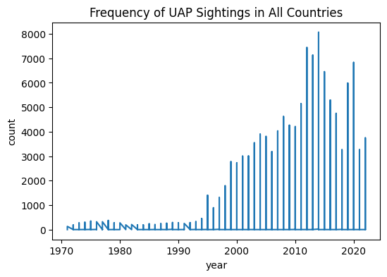

```python
compare_df = ufo_df.copy()

# extract the year and month from the date_time column
compare_df["year"] = pd.DatetimeIndex(compare_df["date_time"]).year
compare_df["month"] = pd.DatetimeIndex(compare_df["date_time"]).month

# get different feature groupings and display the frequencies for each group
freq_ctry = compare_df.groupby(["year", "country"]).size()

# reset index to get a dataframe with a column for frequency
freq_ctry = freq_ctry.reset_index(name="frequency")
freq_ctry["frequency"] = freq_ctry["frequency"].astype(int)

# filter by the year condition (recent years 1970 and on)
freq_ctry = freq_ctry.query("year > 1970")
# plot a line graph of frequency by year for each country
freq_ctry.plot(x="year", y="frequency", ylabel="count", legend=False, kind="line", title="Frequency of UAP Sightings in All Countries")
plt.show()
```

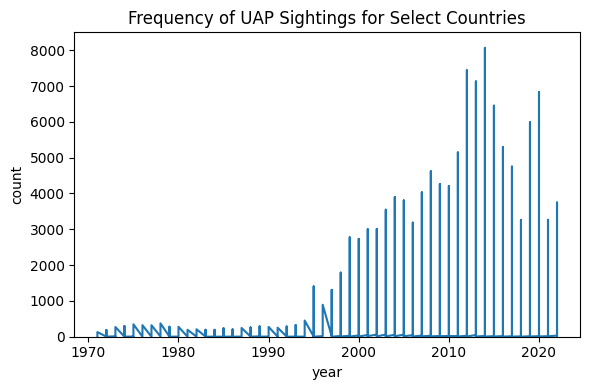

```python
# define the list of countries you want to show
countries = ["USA", "Canada", "United Kingdom", "Australia", "China", "Russia", "Japan"]

# filter the DataFrame by the countries list
freq_ctry = freq_ctry[freq_ctry["country"].isin(countries)]

# filter the DataFrame by the countries list and the year condition
#frequency1d_filtered = frequency1d.query("country in @countries and year > 1970")

# plot a line graph of frequency by year for each country
freq_ctry.plot(x="year", y="frequency", ylabel="count", kind="line", legend=False,  title="Frequency of UAP Sightings for Select Countries")
plt.ylim(0, 8500)
plt.tight_layout()
# save as png file
plt.savefig("plots/recent_yr_freq_line.png")
plt.show()
```

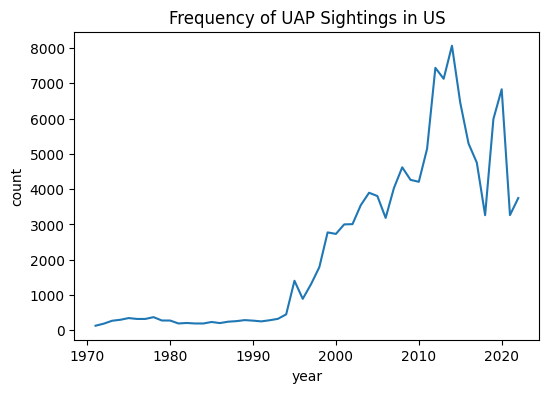

```python
# filter the dataFrame by the country and the year condition
freq_ctry = freq_ctry.query("country == \"USA\" and year > 1970")

# plot a line graph of frequency by year for each country
freq_ctry.plot(x="year", y="frequency", ylabel="count", kind="line", legend=False, title="Frequency of UAP Sightings in US")
# save as png file
plt.savefig("plots/us_freq_line.png")
plt.show()
```

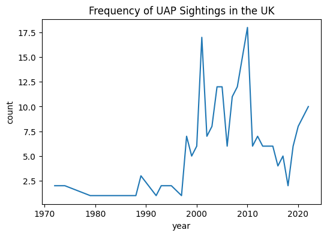

```python
compare_df = ufo_df.copy()

# extract the year and month from the date_time column
compare_df["year"] = pd.DatetimeIndex(compare_df["date_time"]).year
# define the list of countries you want to show
countries = ["USA", "Canada", "United Kingdom", "Australia", "China", "Russia", "Japan"]
# filter the DataFrame by the countries list
compare_df = compare_df[compare_df["country"].isin(countries)]
# get different feature groupings and display the frequencies for each group
freq_ctry = compare_df.groupby(["year", "country"]).size()
# reset index to get a dataframe with a column for frequency
freq_ctry = freq_ctry.reset_index(name="frequency")
freq_ctry["frequency"] = freq_ctry["frequency"].astype(int)
# filter by the year condition (recent years 1970 and on)
freq_ctry = freq_ctry.query("country == \"United Kingdom\" and year > 1970")

# plot a line graph of frequency by year for each country
freq_ctry.plot(x="year", y="frequency", ylabel="count", legend=False, kind="line", title="Frequency of UAP Sightings in the UK")
plt.show()
```

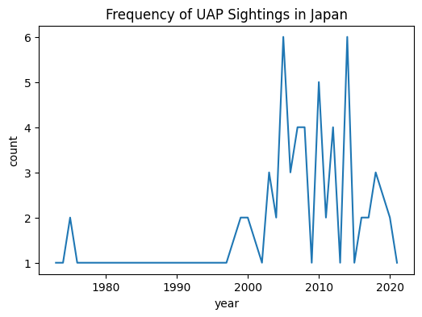

```python
compare_df = ufo_df.copy()

# extract the year and month from the date_time column
compare_df["year"] = pd.DatetimeIndex(compare_df["date_time"]).year
# define the list of countries you want to show
countries = ["USA", "Canada", "United Kingdom", "Australia", "China", "Russia", "Japan"]
# filter the DataFrame by the countries list
compare_df = compare_df[compare_df["country"].isin(countries)]
# get different feature groupings and display the frequencies for each group
freq_ctry = compare_df.groupby(["year", "country"]).size()
# reset index to get a dataframe with a column for frequency
freq_ctry = freq_ctry.reset_index(name="frequency")
freq_ctry["frequency"] = freq_ctry["frequency"].astype(int)

# filter the DataFrame by the country and the year condition
freq_ctry = freq_ctry.query("country == \"Japan\" and year > 1970")
# plot a line graph of frequency by year for each country
freq_ctry.plot(x="year", y="frequency", ylabel="count", legend=False, kind="line", title="Frequency of UAP Sightings in Japan")
plt.show()
```

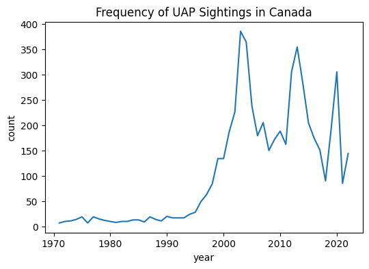

```python
compare_df = ufo_df.copy()

# extract the year and month from the date_time column
compare_df["year"] = pd.DatetimeIndex(compare_df["date_time"]).year
# define the list of countries you want to show
countries = ["USA", "Canada", "United Kingdom", "Australia", "China", "Russia", "Japan"]
# filter the DataFrame by the countries list
compare_df = compare_df[compare_df["country"].isin(countries)]
# get different feature groupings and display the frequencies for each group
freq_ctry = compare_df.groupby(["year", "country"]).size()
# reset index to get a dataframe with a column for frequency
freq_ctry = freq_ctry.reset_index(name="frequency")
freq_ctry["frequency"] = freq_ctry["frequency"].astype(int)
# filter by the year condition (recent years 1970 and on)
freq_ctry = freq_ctry.query("country == \"Canada\" and year > 1970")

# plot a line graph of frequency by year for each country
freq_ctry.plot(x="year", y="frequency", ylabel="count", legend=False, kind="line", title="Frequency of UAP Sightings in Canada")
plt.show()
```

# Supplemental Question: Which shapes are most numerous in UFO sightings?

```
Top UFO Shapes in Sightings
         shape  count
1       light  28336
2      circle  14925
3    triangle  12458
4    fireball   9591
5       other   9552
6     unknown   9433
7      sphere   9107
8        disk   8198
9        oval   6051
10  formation   4641
```

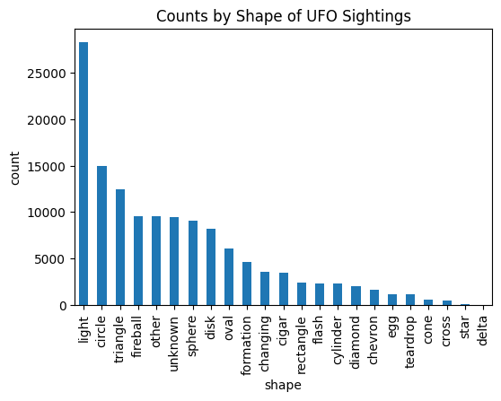

```python
compare_df = ufo_df.copy()  # Need to make copy of ufo_df because this block may alter the actual dataframe
# group by shape
top_shapes = compare_df.groupby("shape").size()
# sort in descending order
top_shapes = top_shapes.sort_values(ascending=False)
# get the top shape values
top_shapes = top_shapes.head(10)
# reset the index to count to get a dataframe
top_shapes = top_shapes.reset_index(name="count")
# add 1 to the index so list starts at 1
top_shapes.index = top_shapes.index + 1
# print table heading
print("Top UFO Shapes in Sightings\n", top_shapes)

# make a bar chart for the counts of UFO shapes in sightings
top_shapes = compare_df.groupby("shape").size()
top_shapes = top_shapes.sort_values(ascending=False)
top_shapes.plot(x="shape", y="count", ylabel="count", kind="bar", subplots=True, label="Counts by Shape of UFO Sightings")
# Save the figure as a PNG file named 'line_plot.png' in your current directory
plt.savefig("plots/topshapes_barplot.png")
plt.show()
```

# Supplemental Question: Most Common UFO Shapes for Countries

```python
compare_df = ufo_df.copy() # copy the ufo_df because this block may alter the actual dataframe
# create a list of countries
countries = ["Japan", "Russia", "USA", "Australia", "Brazil", "Canada", "China", "France", "Germany", "India", "Italy", "Mexico", "New Zealand", "Philippines", "South Africa", "United Kingdom"]
countries.sort()

# filter by country
compare_df = compare_df.loc[compare_df['country'].isin(countries)]

# group by country and find the shape with the highest count for each country
top_shapes = compare_df.groupby("country")["shape"].value_counts().groupby("country").idxmax()

# convert series to dataframe
top_shapes = top_shapes.to_frame()

# rename the column
top_shapes.columns = ["shape"]


# reset the index
top_shapes = top_shapes.reset_index()

# set country as the index of the dataframe
top_shapes = top_shapes.set_index("country")

# reindex the dataframe with the list of countries
top_shapes = top_shapes.reindex(countries)

# apply a function to extract the second element of each tuple in the shape column
top_shapes["shape"] = top_shapes["shape"].apply(lambda x: x[1])

# reset the index again
top_shapes = top_shapes.reset_index()
top_shapes.index = top_shapes.index + 1

# print the result with a tab separator
print("Most Common Shapes for Select Countries")
print(top_shapes.to_string(index=False, header=True))
# save table to file
top_shapes.to_csv("data/topshape_countries.csv")
```

```
Most Common Shapes for Select Countries
       country    shape
     Australia    light
        Brazil    light
        Canada    light
         China   circle
        France triangle
       Germany    light
         India   circle
         Italy     disk
         Japan    light
        Mexico    light
   New Zealand    light
   Philippines   circle
        Russia    light
  South Africa    light
           USA    light
United Kingdom    light
```

# Supplemental Question: What are the 3 Most Common UFO Shapes for Countries?

```python
compare_df = ufo_df.copy()
# create a list of countries
countries = ["Japan", "Russia", "USA", "Australia", "New Zealand", "Brazil", "Canada", "China", "France", "Germany", "India", "Italy", "Mexico", "Philippines", "South Africa", "United Kingdom"]
countries.sort()

# filter by country
compare_df = compare_df.loc[compare_df["country"].isin(countries)]
# group by country and find the top 4 most common shapes for each country
top_shapes = compare_df.groupby("country")["shape"].value_counts().groupby("country").nlargest(3)
# rename the index levels
top_shapes.index.names = ["country","", "shape2"]
# reset the index
top_shapes = top_shapes.reset_index()
# rename the last column
top_shapes.columns = ["country", "", "shape", "count"]

# set the country and shape as the index of the series
top_shapes = top_shapes.set_index(["country", "shape"])["count"]

# print the result with a tab separator
print("3 Most Common Shapes for Select Countries")
print(top_shapes, sep="\t")
```

```
3 Most Common Shapes for Select Countries
country         shape
Australia       light         178
                circle         95
                disk           87
Brazil          light          29
                circle         17
                triangle       14
Canada          light        1243
                circle        573
                triangle      474
China           circle         10
                light           7
                triangle        6
France          triangle       16
                light          15
                other          13
Germany         light          35
                circle         18
                oval           18
India           circle         58
                light          54
                triangle       46
Italy           disk            9
                circle          8
                fireball        7
Japan           light          22
                disk            8
                other           7
Mexico          light          83
                disk           43
                sphere         43
New Zealand     light          40
                circle         27
                disk           16
Philippines     circle         15
                light          14
                disk           13
Russia          light           7
                disk            6
                other           4
South Africa    light          48
                disk           21
                circle         20
USA             light       25343
                circle      13246
                triangle    11247
United Kingdom  light          50
                circle         38
                triangle       18
Name: count, dtype: int64
```

# Supplemental Question: What are the four longest durations of UFO sightings?

```python
# get the longest duration times
compare_df = ufo_reset_df.copy()

# convert the duration column to a timedelta type
compare_df["duration"] = pd.to_timedelta(compare_df["duration"])

# get the 4 largest values in the duration column
longest_4 = compare_df["duration"].nlargest(4)

# reset index to get a dataframe
longest_4 = longest_4.reset_index(name="count")
longest_4.index = longest_4.index + 1

# print without row index numbers
print("Longest Duration of UFO Sightings")
#print(longest_4['count'].to_string(index=True))
print(longest_4['count'])
```

```
Longest Duration of UFO Sightings
1   100 days 00:00:00
2    70 days 20:00:00
3    12 days 12:04:00
4     4 days 00:00:00
Name: count, dtype: timedelta64[ns]
```

# Supplemental Question: What is the average duration of UFO sightings?

```python
compare_df = normal_df_dur.copy()  # copy duration_df in case we alter it

# get the mean value of the duration column
duration_mean = compare_df["duration"].mean()

# get only the numeric value in seconds
duration_mean_seconds = duration_mean.total_seconds()

# get the mean in minutes by dividing by 60
duration_mean_min = duration_mean_seconds / 60

# alternative: use the components attribute to get the minutes component
#duration_mean_min = duration_mean.components.minutes

print("Average duration of UFO sighting in minutes: ", round(duration_mean_min))
print("Average duration of UFO sighting in seconds: ", round(duration_mean_seconds))
```

```
Average duration of UFO sighting in minutes:  23
Average duration of UFO sighting in seconds:  1401
```

# What are the descriptive stats of UFO sightings regarding city latitude and city longitude?

```python
print("Descriptive stats for city latitude and longitude of UFO sightings\n", stats_lat_long)
```

```
Descriptive stats for city latitude and longitude of UFO sightings
        city_latitude  city_longitude
count  115440.000000   115440.000000
mean       38.697147      -95.102130
std         5.736872       18.123691
min       -31.941922     -176.627400
25%        34.223597     -112.975200
50%        39.273300      -89.081250
75%        42.352576      -80.332976
max        70.639300      130.879729
```

# What is the range of city latitude and city longitude readings that UFO sightings occur?

```python
print("Range of city latitude where UFO sightings occur: ", city_lat_max, "to", city_lat_min)
print("Range of city longitude where UFO sightings occur: ", city_long_max, "to", city_long_min)
```

```
Range of city latitude where UFO sightings occur:  71 to -32
Range of city longitude where UFO sightings occur:  131 to -177
```

# What are the highest frequencies and probabilities of UFO sightings given year, city, and country?

```python
# copy ufo_reset_df to ufo_cities
ufo_cities = ufo_reset_df.copy()

# subset the ufo_cities with columns needed
ufo_cities = ufo_cities[["city","state","country","year","freq","percent_prob"]]
# get the top prob values
high_prob =ufo_cities.groupby(["year","city","country","freq","percent_prob"]).size()
# sort in descending order
high_prob = high_prob.sort_values(ascending=False)
# get the top shape values
high_prob = high_prob.head(15)
# reset the index to count to get a dataframe
high_prob = high_prob.reset_index(name="count")
# add 1 to the index so list starts at 1
high_prob.index = high_prob.index + 1

print("Top Cities with Highest Frequencies & Probabilities of UFO Sightings based on year, city, and country")
print(high_prob)
```

```
Top Cities with Highest Frequencies & Probabilities of UFO Sightings based on year, city, and country
    year          city country  freq  percent_prob  count
1   2004   Tinley Park     USA  93.0        0.0142     93
2   2014      Portland     USA  53.0        0.0081     53
3   1997       Phoenix     USA  52.0        0.0079     52
4   2014      New York     USA  52.0        0.0079     52
5   2012       Seattle     USA  48.0        0.0073     48
6   2003      New York     USA  48.0        0.0073     48
7   2001      New York     USA  47.0        0.0072     47
8   2014  Myrtle Beach     USA  47.0        0.0072     47
9   2015     Las Vegas     USA  46.0        0.0070     46
10  2014     Las Vegas     USA  45.0        0.0069     45
11  2005       Phoenix     USA  45.0        0.0069     45
12  2014       Phoenix     USA  45.0        0.0069     45
13  2015       Phoenix     USA  44.0        0.0067     44
14  2016       Phoenix     USA  44.0        0.0067     44
15  2012     Las Vegas     USA  44.0        0.0067     44
```

# Create a bar chart for top frequencies and probabilities in a year, city and country

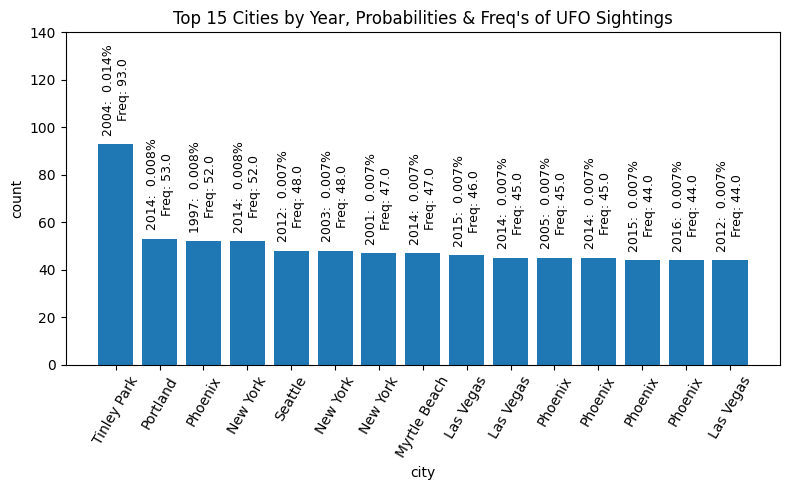

```python
from matplotlib.container import BarContainer
# make a bar chart for highest frequencies and probabilities in a year, city and country
ufo_cities = ufo_reset_df.copy()

# subset the ufo_cities with columns needed
ufo_cities = ufo_cities[["city","state","country","year","freq","prob","percent_prob"]]
# get the top prob values
high_prob = ufo_cities.groupby(["year","city","country","freq","prob","percent_prob"]).size()
# sort in descending order
high_prob = high_prob.sort_values(ascending=False)
# get the top shape values
high_prob = high_prob.head(15)
# reset the index to count to get a dataframe
high_prob = high_prob.reset_index(name="count")

# make fig and ax objects and set figure size
fig, ax = plt.subplots(figsize=(8,5))

# get x and y values from high_prob dataframe
x = high_prob["city"]
y = high_prob["count"]

# make a bar chart with the x and y values; for x values use np.arange() to create an array of values
bar_container = ax.bar(np.arange(15), y)

# convert bar_container object into a BarContainer object to use bar_container.patches
bar_container = BarContainer(bar_container)

# set the labels and title
ax.set(xlabel="city", ylabel="count", title="Top 15 Cities by Year, Probabilities & Freq's of UFO Sightings")

# subset high_prob["year","percent_prob","count"] into a list
yr_count = high_prob[["year","percent_prob","count"]]

# make an empty list to store the labels
label_list = list()

# iterate over the rows of the yr_count dataframe
for index, row in yr_count.iterrows():
    # assign the values of the year, percent_prob, and count columns from each row
    year = int(row["year"])
    year = str(year)
    freq = str(row["count"])
    per_prob = str(round(row["percent_prob"], 3))
    # combine the year and count values into a single string
    label = year + ":  " + per_prob + "%\nFreq: " + freq
    # append this string to the label_list
    label_list.append(label)

# format the bar_label object with bar_container.patches and label_list, slicing it to 15 items
ax.bar_label(bar_container.patches, labels=label_list[:15], fontsize=9, rotation=90, padding=6)

# set the xticks and xticklabels
# use np.arange() to create even-spaced xtick marks
ax.set_xticks(np.arange(15))
# use the cities in high_prob["city"] as the xticklabels
ax.set_xticklabels(high_prob["city"], rotation=60)
# set the y-axis limit
plt.ylim(0, 140)
plt.tight_layout()
plt.savefig("plots/top_us_cities_prob_barchart.png")
plt.show()
```